# Final Project Notebook

3/26/2021

### Introduction of the Project

The goal of this project is to predict in-hospital ‘death’ of Subarachnoid Hemorrhage (SAH) patients using all patients’ records in the first 3 days from the start time of the hospitalization. No information after the first 3 days should be used as variables. Inputs of prediction includes patients’ encounter data, medications, and procedures. A test set will be given but the outcome will not be included in the dataset provided to students.

### Outcome

The primary outcome is mortality; defined as in-hospital death or discharge to hospice care.

### Task

Build a machine-learning model to predict mortality in subarachnoid hemorrhage patients.

#### Importing datasets

```r
### loading packages
library(dplyr)
library(readr)
library(tidyr)
library(lubridate)
library(ggplot2)
```

```r
library(readr)
demo_train <- read_csv("demo_train.csv")
medication_train <- read_csv("medication_train.csv")
procedure_train <- read_csv("procedure_train.csv")
```

#### Viewing top 5 rows for each datasets

```r
# head(demo_train, n=5)
```

```r
# head(medication_train, n=5)
```

```r
# head(procedure_train, n=5)
```

#### Renaming columns

```r
demo_train <- demo_train %>%
  rename(
    patient_num = patient_sk,
    age = age_in_years,
    admission_date = New_admitted_dt_tm,
    discharge_date = New_discharge_dt_tm
  )

medication_train <- medication_train %>%
  rename(
    patient_num = patient_sk,
    medication_date = med_started_dt_tm
  )

procedure_train <- procedure_train %>%
  rename(
    patient_num = patient_sk,
    procedure_date = procedure_dt_tm
  )
```

#### To combine all prediction variables into one dataset, we first:

```r
medication_train <- demo_train %>%
  select(patient_num, admission_date) %>%
  right_join(medication_train)
procedure_train <- demo_train %>%
  select(patient_num, admission_date) %>%
  right_join(procedure_train)
```

#### Rearranging columns order

```r
# colnames(medication_train)
medication_train <- medication_train[,c(1,3,2,4)]

# colnames(procedure_train)
procedure_train <- procedure_train[,c(1,3,4,2,5)]
```

#### Calculating the date intervals in days

```r
demo_train <- demo_train %>%
  mutate(
    days_dis_adm = as.numeric(difftime(discharge_date, admission_date, units ="days"))
  )
```

```r
medication_train <- medication_train %>%
  mutate(
    days_med_adm = as.numeric(difftime(medication_date, admission_date, units ="days"))
  )
```

```r
procedure_train <- procedure_train %>%
  mutate(
    days_pro_adm = as.numeric(difftime(procedure_date, admission_date, units ="days"))
  )
```

#### Missing Data

```r
demo_train[!complete.cases(demo_train),]  ## no missing data
```

```
## # A tibble: 0 x 8
## # ... with 8 variables: patient_num <dbl>, gender <chr>, race <chr>, age <dbl>,
## #   death <lgl>, admission_date <dttm>, discharge_date <dttm>,
## #   days_dis_adm <dbl>
```

```r
procedure_train[!complete.cases(procedure_train),] ## no missing data
```

```
## # A tibble: 0 x 6
## # ... with 6 variables: patient_num <dbl>, procedure_id <dbl>,
## #   procedure_description <chr>, admission_date <dttm>, procedure_date <dttm>,
## #   days_pro_adm <dbl>
```

```r
medication_train[!complete.cases(medication_train),] # no missing data
```

```
## # A tibble: 0 x 5
## # ... with 5 variables: patient_num <dbl>, generic_name <chr>,
## #   admission_date <dttm>, medication_date <dttm>, days_med_adm <dbl>
```

#### Descriptive Analysis

- Age

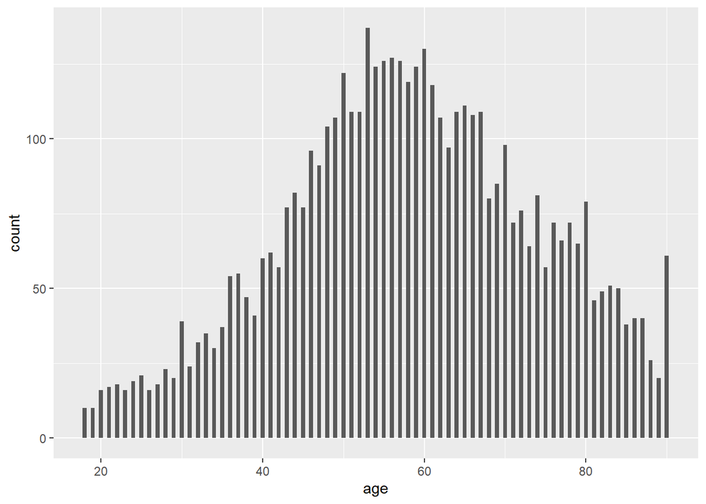

```r
ggplot(data = demo_train) + geom_histogram(mapping=aes(x=age), binwidth=0.5)
```

- Race by Death

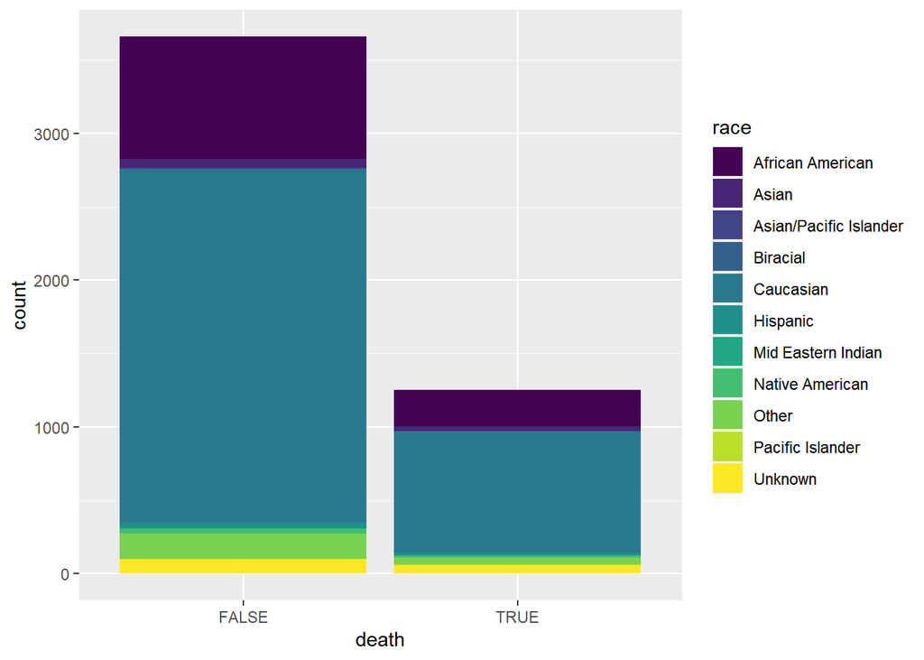

```r
ggplot(demo_train, aes(x = death, fill = race)) +
  geom_bar() +
  scale_fill_viridis_d()
```

- Death by age

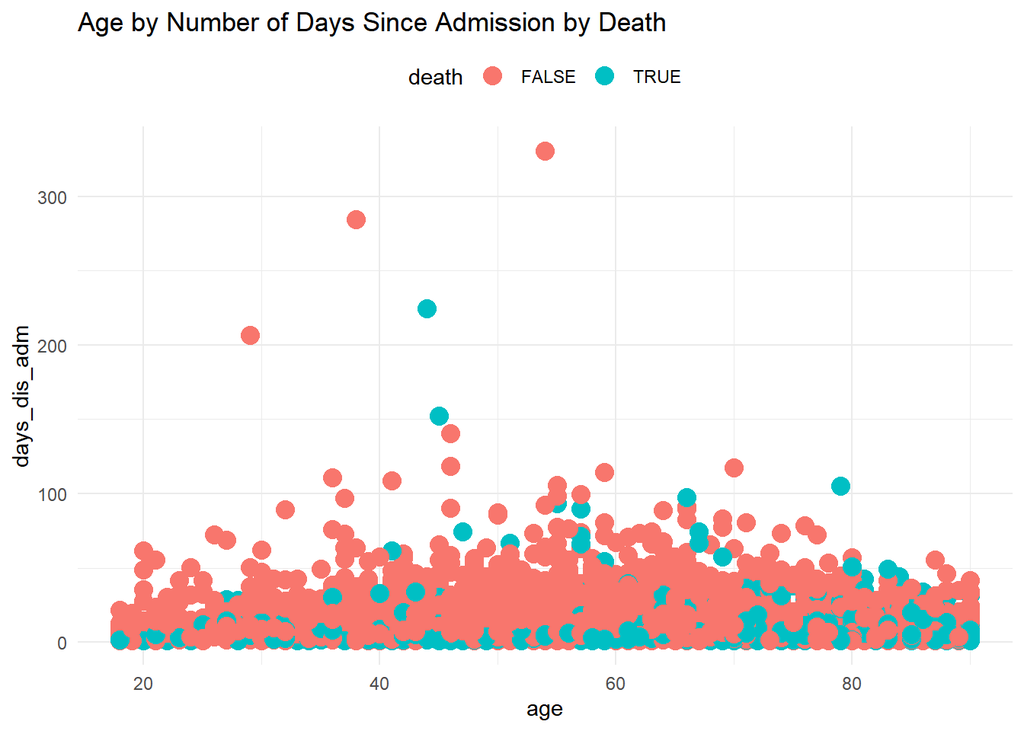

```r
ggplot(demo_train,
       aes(x= age, y= days_dis_adm, color = death)) +
  geom_point(size = 4) +
  labs(title = "Age by Number of Days Since Admission by Death") +
  theme_minimal() +
  theme(legend.position = "top")
```

- Deaths

```r
demo_train %>%
  group_by(death) %>%
  summarize(Frequency = n()) %>%
  mutate(Relative_Percentage = (Frequency / sum(Frequency))*100)
```

```
## # A tibble: 2 x 3
##   death Frequency Relative_Percentage
##   <lgl>     <int>               <dbl>
## 1 FALSE      3659                74.5
## 2 TRUE       1252                25.5
```

- Gender

```r
demo_train %>%
  group_by(gender) %>%
  summarize(Frequency = n()) %>%
  mutate(Relative_Percentage = (Frequency / sum(Frequency))*100)
```

```
## # A tibble: 3 x 3
##   gender  Frequency Relative_Percentage
##   <chr>       <int>               <dbl>
## 1 Female       2877             58.6
## 2 Male         2033             41.4
## 3 Unknown         1              0.0204
```

- Race

```r
demo_train %>%
  group_by(race) %>%
  summarize(Frequency = n()) %>%
  mutate(Relative_Percentage = (Frequency / sum(Frequency))*100)
```

```
## # A tibble: 11 x 3
##    race                   Frequency Relative_Percentage
##    <chr>                      <int>               <dbl>
##  1 African American            1081             22.0
##  2 Asian                         94              1.91
##  3 Asian/Pacific Islander         1              0.0204
##  4 Biracial                       5              0.102
##  5 Caucasian                   3243             66.0
##  6 Hispanic                      51              1.04
##  7 Mid Eastern Indian             3              0.0611
##  8 Native American               53              1.08
##  9 Other                        218              4.44
## 10 Pacific Islander               4              0.0814
## 11 Unknown                      158              3.22
```

#### Combining all dataframes into one by id and admission date (WHEN THE SMALLER DATASETS ARE CLEANED)

```r
# joined_df <- demo_train %>%
#   left_join(medication_train, by = c('patient_num', 'admission_date')) %>%
#   left_join(procedure_train, by = c('patient_num', 'admission_date')) %>%
#   select(-procedure_description)
```